# ML_HW2

2022-10-09

# Donovan Rasamoelison - PSTAT 231 - HW2

## Question 1 - Distribution of age

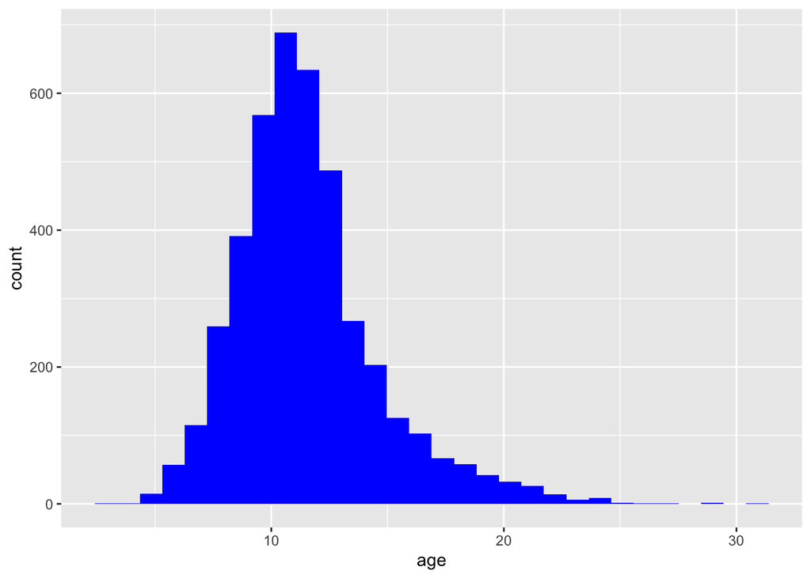

```r
rm(list=ls())
setwd("~/Desktop/2nd Year PhD/Machine learning/ML-HW2/Machine_Learning_HW2")

library(tidyverse)
library(ggplot2)
library(tidymodels)
library(yardstick)


abalone <- read_csv("abalone.csv")


abalone <- abalone %>%
  mutate(age = rings + 1.5)

abalone <- abalone %>%
  select(-c(rings))

ggplot(abalone, aes(x = age)) +
  geom_histogram(fill='blue')
```

## Question 2 - Splitting the data

```r
set.seed(1)

    #splitting the data
abalone_split <- initial_split(abalone, prop = 0.80, strata = age)
abalone_train <- training(abalone_split)
abalone_test  <- testing(abalone_split)
```

## Question 3 - Using the training data

```r
abalone_recipe <- recipe(age ~ ., data = abalone_train) %>%
  step_dummy(all_nominal_predictors()) %>%
  step_interact(terms = ~ type_M:shucked_weight) %>%
  step_interact(terms = ~ longest_shell:diameter) %>%
  step_interact(terms = ~ shucked_weight:shell_weight) %>%
  step_center(all_predictors()) %>%
  step_scale(all_predictors())
```

## Question 4 - Creating lm engine

```r
lm_model <- linear_reg() %>%
  set_engine("lm")
```

## Question 5 - Setting the workflow

```r
lm_workflow <- workflow() %>%
  add_model(lm_model) %>%
  add_recipe(abalone_recipe)
```

## Question 6 - Fitting the model

```r
lm_fit <- fit(lm_workflow, abalone_train)

lm_fit %>%
  extract_fit_parsnip() %>%
  tidy()
```

```
## # A tibble: 13 × 5
##    term                          estimate std.error statistic  p.value
##    <chr>                            <dbl>     <dbl>     <dbl>    <dbl>
##  1 (Intercept)                     11.4      0.0374    305.   0
##  2 longest_shell                    0.899    0.280       3.20 1.37e- 3
##  3 diameter                         2.41     0.308       7.83 6.67e-15
##  4 height                           0.206    0.0698      2.95 3.21e- 3
##  5 whole_weight                     5.18     0.392      13.2  6.50e-39
##  6 shucked_weight                  -4.17     0.248     -16.8  5.18e-61
##  7 viscera_weight                  -1.01     0.156      -6.45 1.25e-10
##  8 shell_weight                     1.79     0.212       8.45 4.45e-17
##  9 type_I                          -0.395    0.0579     -6.83 1.01e-11
## 10 type_M                          -0.102    0.0958     -1.07 2.86e- 1
## 11 type_M_x_shucked_weight          0.125    0.101       1.24 2.15e- 1
## 12 longest_shell_x_diameter        -3.42     0.383      -8.91 7.92e-19
## 13 shucked_weight_x_shell_weight   -0.316    0.203      -1.56 1.20e- 1
```

```r
abalone_train_res <- predict(lm_fit, new_data = data.frame(
  type = "I" , longest_shell = 0.5, diameter = 0.1,
  height = 0.3, whole_weight = 4, shucked_weight = 1,
  viscera_weight = 2, shell_weight = 1))

abalone_train_res
```

```
## # A tibble: 1 × 1
##   .pred
##   <dbl>
## 1  22.7
```

## Question 7 - Assessing model performance

```r
abalone_train_res2 <- predict(lm_fit, new_data = abalone_train %>% select(-age))

abalone_train_res2 <- bind_cols(abalone_train_res2, abalone_train %>% select(age))

abalone_metrics <- metric_set(rmse,rsq, mae)

abalone_metrics(abalone_train_res2, truth = age, estimate = .pred)
```

```
## # A tibble: 3 × 3
##   .metric .estimator .estimate
##   <chr>   <chr>          <dbl>
## 1 rmse    standard       2.16
## 2 rsq     standard       0.560
## 3 mae     standard       1.56
```

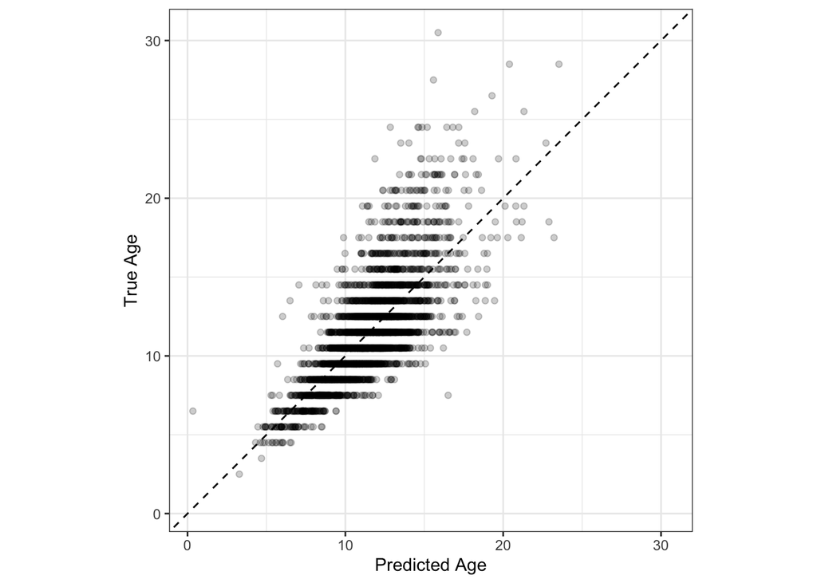

```r
#Graphing

abalone_train_res2 %>%
  ggplot(aes(x=.pred, y = age)) +
  geom_point(alpha = 0.2) +
  geom_abline(lty=2) +
  theme_bw() +
  coord_obs_pred() +
  ylab("True Age") +
  xlab("Predicted Age")
```

# Only for 231 students

## Question 8 - reproducible and irreducible error

The reproducible error is
$$Var(\hat{f}(x_0)) + [Bias(\hat{f}(x_0))]^2$$
and the irreducible error is
$$Var(\epsilon)$$

## Question 9 - Expected test error > irreducible error

The formula of the expected test error is:
$$E[(y-\hat{f}(x_0))^2] = Var(\hat{f}(x_0)) +
[Bias(\hat{f}(x_0))]^2 + Var(\epsilon)$$

Because $Var(\hat{f}(x_0)) + [Bias(\hat{f}(x_0))]^2$ is positive by construction, it has to be the case that $E[(y-\hat{f}(x_0))^2] > Var(\epsilon)$

## Question 10 - Proof of the bias-variance tradeoff

$$E[(y-\hat{f}(x))^2] = E[(f(x) + \epsilon
-\hat{f}(x))^2]$$
$$E[(y-\hat{f}(x))^2] = E[(f(x) -\hat{f}(x))^2] +
2E[\epsilon(f(x) - \hat{f}(x))] + E[\epsilon^2]$$
The middle term is 0. Because the mean of $\epsilon$ is 0, $Var(\epsilon) = E[\epsilon^2]$. Thus, we have:
$$E[(y-\hat{f}(x))^2] = E[(f(x) -\hat{f}(x))^2] +
Var(\epsilon)$$
Thus, to complete the proof, we just need to show that $E[(f(x) -\hat{f}(x))^2] = Var(\hat{f}(x_0)) + [Bias(\hat{f}(x_0))]^2$.

$$E[(f(x) -\hat{f}(x))^2] = E[(f(x) -
E(\hat{f}(x)) + E(\hat{f}(x)) -\hat{f}(x))^2]$$

Combining terms (to simplify notations, let $f(x) = f$):
$$E[(f-\hat{f})^2] = E[( [f - E(\hat{f})] - [ \hat{f} - E(\hat{f})])^2]$$
Expanding the square and applying the linearity of expectations:

$$E[(f-\hat{f})^2] = E[(f -
E(\hat{f}))^2] + E[(\hat{f} -E(\hat{f}))^2] +2E[ (f - E(\hat{f}))
(\hat{f} - E(\hat{f}))]$$
Because the third term is zero, we have:

$$E[(f-\hat{f})^2] = E(Bias(\hat{f})^2) +
Var(\hat{f})$$
Which is equivalent to:
$$E[(f-\hat{f})^2] = Bias(\hat{f})^2 +
Var(\hat{f})$$